# Regresión lineal múltiple

Osmar Dominique

2025-09-18

Consideraremos la tabla cocodrilos.xls que trata sobre el estudio de 11 variables medidas en 44 cráneos de cocodrilos. Las variables son:

CL = Longitud del cráneo.

CW = Ancho del cráneo.

SW = Ancho del hocico.

SL = Longitud del hocico.

DCL = Longitud dorsal del cráneo.

OW = Ancho máximo orbital.

OIW = Ancho mínimo inter-orbital.

OL = Longitud máxima orbital.

LCR = Longitud del paladar post-orbital.

WCR = Ancho posterior del paladar craneal.

WN = Ancho máximo en los orificios nasales.

1. **Obtener la matriz de dispersión de las 11 variables**

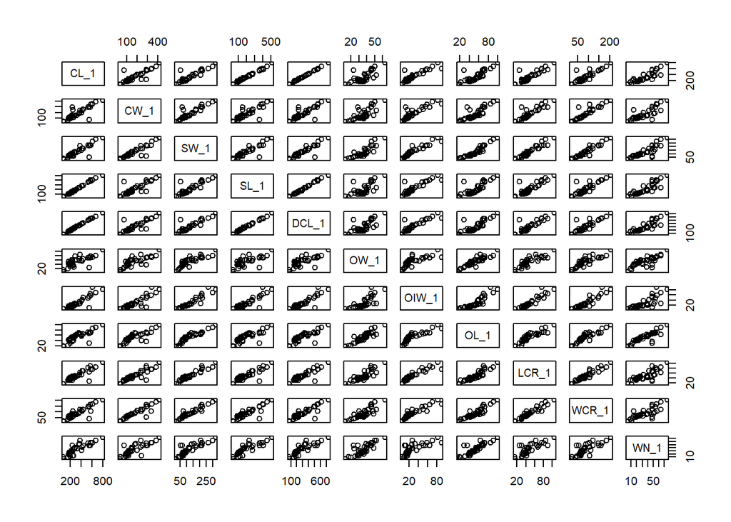

2. **De la matriz de correlación, entre qué par de variables se da la mayor y menor relación lineal?**

   La matriz de correlación es:

   ```
   ##            CL_1      CW_1      SW_1      SL_1     DCL_1      OW_1     OIW_1
   ## CL_1  1.0000000 0.8713206 0.9109048 0.9970786 0.9990275 0.7377772 0.9027890
   ## CW_1  0.8713206 1.0000000 0.9076462 0.8696425 0.8717564 0.7695723 0.8924942
   ## SW_1  0.9109048 0.9076462 1.0000000 0.9027671 0.9090733 0.8593097 0.9517970
   ## SL_1  0.9970786 0.8696425 0.9027671 1.0000000 0.9976942 0.7132771 0.8975664
   ## DCL_1 0.9990275 0.8717564 0.9090733 0.9976942 1.0000000 0.7371382 0.9013121
   ## OW_1  0.7377772 0.7695723 0.8593097 0.7132771 0.7371382 1.0000000 0.7659377
   ## OIW_1 0.9027890 0.8924942 0.9517970 0.8975664 0.9013121 0.7659377 1.0000000
   ## OL_1  0.8444986 0.8542296 0.9498606 0.8319391 0.8440251 0.9061540 0.8947648
   ## LCR_1 0.8860810 0.8910728 0.9562891 0.8809688 0.8871726 0.8560446 0.9318666
   ## WCR_1 0.8859551 0.9162014 0.9593303 0.8816841 0.8839405 0.8408712 0.9323102
   ## WN_1  0.8781103 0.8320095 0.8730057 0.8701779 0.8809148 0.8024919 0.7752994
   ##            OL_1     LCR_1     WCR_1      WN_1
   ## CL_1  0.8444986 0.8860810 0.8859551 0.8781103
   ## CW_1  0.8542296 0.8910728 0.9162014 0.8320095
   ## SW_1  0.9498606 0.9562891 0.9593303 0.8730057
   ## SL_1  0.8319391 0.8809688 0.8816841 0.8701779
   ## DCL_1 0.8440251 0.8871726 0.8839405 0.8809148
   ## OW_1  0.9061540 0.8560446 0.8408712 0.8024919
   ## OIW_1 0.8947648 0.9318666 0.9323102 0.7752994
   ## OL_1  1.0000000 0.9219573 0.9259473 0.8644945
   ## LCR_1 0.9219573 1.0000000 0.9538411 0.8055277
   ## WCR_1 0.9259473 0.9538411 1.0000000 0.7981871
   ## WN_1  0.8644945 0.8055277 0.7981871 1.0000000
   ```

   La mayor relación lineal se da entre la longitud del cráneo (CL) y la longitud dorsal del cráneo (DCL), con una correlación de 0.9990275 mientras que la menor se da entre la longitud del hocico (SL) y la ancho máximo orbital (OW) con una correlación de 0.7132771.
3. **Realizar una regresión lineal múltiple entre la variable dependiente CW y las variables independientes WN, WCR, OW y LCR.**

   ```
   ##
   ## Call:
   ## lm(formula = CW_1 ~ WN_1 + WCR_1 + OW_1 + LCR_1, data = cocodrilos)
   ##
   ## Residuals:
   ##     Min      1Q  Median      3Q     Max
   ## -61.217 -13.573  -3.773   3.073 146.997
   ##
   ## Coefficients:
   ##             Estimate Std. Error t value Pr(>|t|)
   ## (Intercept)  -0.1968    23.6551  -0.008  0.99340
   ## WN_1          1.8327     0.5875   3.119  0.00340 **
   ## WCR_1         1.5751     0.4501   3.500  0.00118 **
   ## OW_1         -1.6969     1.1655  -1.456  0.15341
   ## LCR_1         0.6604     0.9863   0.670  0.50704
   ## ---
   ## Signif. codes:  0 '***' 0.001 '**' 0.01 '*' 0.05 '.' 0.1 ' ' 1
   ##
   ## Residual standard error: 35.01 on 39 degrees of freedom
   ## Multiple R-squared:  0.8745, Adjusted R-squared:  0.8616
   ## F-statistic: 67.93 on 4 and 39 DF,  p-value: < 2.2e-16
   ```

   1. **¿Esta regresión se ajusta bien a los datos?**

      Las únicas variables que son significativas para el modelo es WN y WCR. Además, se obtiene un coeficiente de determinación ajustado ($R^2$ ajustado) de 0.8616, es decir, el modelo explica el 86.16% de la variabilidad total.

      ```
      ## Analysis of Variance Table
      ##
      ## Response: CW_1
      ##           Df Sum Sq Mean Sq  F value    Pr(>F)
      ## WN_1       1 263648  263648 215.0821 < 2.2e-16 ***
      ## WCR_1      1  66702   66702  54.4148 6.551e-09 ***
      ## OW_1       1   2157    2157   1.7594    0.1924
      ## LCR_1      1    550     550   0.4484    0.5070
      ## Residuals 39  47806    1226
      ## ---
      ## Signif. codes:  0 '***' 0.001 '**' 0.01 '*' 0.05 '.' 0.1 ' ' 1
      ```

      Después, del ANOVA del modelo, se obtiene que el modelo solo es significativo para WN y WCR. Por lo tanto, el modelo solo se ajusta bien a las variables WN y WCR.
   2. **Colocar la ecuación de regresión.**

      La ecuación de regresión es:
      $$Y = 0 +
      1.8327*WN + 1.5751*WCR - 1.6969*OW + 0.6604*LCR$$
   3. **Predecir el valor de la variable CW cuando las variables independientes toman los siguientes valores:**

      | WN | WCR | OW | LCR |
      | --- | --- | --- | --- |
      | 30 | 100 | 40 | 45 |
      | 45 | 140 | 48 | 65 |
      | 60 | 180 | 51 | 87 |

      ```
      ##        fit      lwr      upr
      ## 1 174.1339 149.8839 198.3840
      ## 2 264.2602 239.0058 289.5145
      ## 3 364.1917 335.1326 393.2508
      ```

      ```
      ##        fit       lwr      upr
      ## 1 174.1339  99.27963 248.9882
      ## 2 264.2602 189.07450 339.4458
      ## 3 364.1917 287.64412 440.7393
      ```

4. **Verificar los supuestos de normalidad y homocedasticidad.**

   ```
   ## Non-constant Variance Score Test
   ## Variance formula: ~ fitted.values
   ## Chisquare = 0.2165982, Df = 1, p = 0.64164
   ```

   De la prueba de homocedasticidad se obtiene un p-value de 0.64164 por lo cual la varianza es constante.

   ```
   ##
   ##  Shapiro-Wilk normality test
   ##
   ## data:  residuals(modelo)
   ## W = 0.68546, p-value = 2.005e-08
   ```

   Por otro lado, de la prueba de normalidad se obtiene un p-value de $2.005*10^{-8}$ por lo que los errores no están distribuidos de manera normal.
5. **Realizar un ajuste del modelo quitando alguna(s) variables. Colocar la nueva ecuación de regresión con el modelo que creas que se ajusto mejor. ¿Hay un cambio significativo en el modelo?**
   - **Modelo 1:** Solo se considerarán las variables WN y WCR, ya que el resto no eran significativas para el modelo.

     ```
     ##
     ## Call:
     ## lm(formula = CW_1 ~ WN_1 + WCR_1, data = cocodrilos)
     ##
     ## Residuals:
     ##     Min      1Q  Median      3Q     Max
     ## -48.073 -15.059  -7.002   6.161 152.076
     ##
     ## Coefficients:
     ##             Estimate Std. Error t value Pr(>|t|)
     ## (Intercept) -24.7710    12.8706  -1.925  0.06124 .
     ## WN_1          1.5717     0.5347   2.939  0.00538 **
     ## WCR_1         1.6228     0.2205   7.358 5.17e-09 ***
     ## ---
     ## Signif. codes:  0 '***' 0.001 '**' 0.01 '*' 0.05 '.' 0.1 ' ' 1
     ##
     ## Residual standard error: 35.1 on 41 degrees of freedom
     ## Multiple R-squared:  0.8674, Adjusted R-squared:  0.8609
     ## F-statistic: 134.1 on 2 and 41 DF,  p-value: < 2.2e-16
     ```

     Las variables explicativas son significativas para el modelo, pero el intercepto no lo es. Además, se obtiene un coeficiente de determinación ajustado ($R^2$ ajustado) de 0.8609, es decir, el modelo explica el 86.09% de la variabilidad total.

     ```
     ## Analysis of Variance Table
     ##
     ## Response: CW_1
     ##           Df Sum Sq Mean Sq F value    Pr(>F)
     ## WN_1       1 263648  263648  214.00 < 2.2e-16 ***
     ## WCR_1      1  66702   66702   54.14 5.171e-09 ***
     ## Residuals 41  50513    1232
     ## ---
     ## Signif. codes:  0 '***' 0.001 '**' 0.01 '*' 0.05 '.' 0.1 ' ' 1
     ```

     Después, del ANOVA del modelo, se obtiene que el modelo es significativo para las variables explicativas. De esta manera, el modelo es significativo.

     ```
     ## Non-constant Variance Score Test
     ## Variance formula: ~ fitted.values
     ## Chisquare = 0.02329515, Df = 1, p = 0.87869
     ```

     De la prueba de homocedasticidad se obtiene un p-value de 0.87869 por lo cual la varianza es constante.

     ```
     ##
     ##  Shapiro-Wilk normality test
     ##
     ## data:  residuals(modelo1)
     ## W = 0.69997, p-value = 3.514e-08
     ```

     Por otro lado, de la prueba de normalidad se obtiene un p-value de $3.514*10^{-8}$ por lo que los errores no están distribuidos de manera normal.
   - **Modelo 2:** Solo se considerará la variable WCR, ya que la variable WN es la que tiene menor correlación con CW.

     ```
     ##
     ## Call:
     ## lm(formula = CW_1 ~ WCR_1, data = cocodrilos)
     ##
     ## Residuals:
     ##     Min      1Q  Median      3Q     Max
     ## -34.564 -16.242  -9.434  -2.105 190.161
     ##
     ## Coefficients:
     ##             Estimate Std. Error t value Pr(>|t|)
     ## (Intercept) -15.8736    13.5999  -1.167     0.25
     ## WCR_1         2.1402     0.1444  14.818   <2e-16 ***
     ## ---
     ## Signif. codes:  0 '***' 0.001 '**' 0.01 '*' 0.05 '.' 0.1 ' ' 1
     ##
     ## Residual standard error: 38.16 on 42 degrees of freedom
     ## Multiple R-squared:  0.8394, Adjusted R-squared:  0.8356
     ## F-statistic: 219.6 on 1 and 42 DF,  p-value: < 2.2e-16
     ```

     La variable WCR es significativa para el modelo, pero el intercepto no lo es. Además, se obtiene un coeficiente de determinación ajustado ($R^2$ ajustado) de 0.8356, es decir, el modelo explica el 83.56% de la variabilidad total.

     ```
     ## Analysis of Variance Table
     ##
     ## Response: CW_1
     ##           Df Sum Sq Mean Sq F value    Pr(>F)
     ## WCR_1      1 319706  319706  219.56 < 2.2e-16 ***
     ## Residuals 42  61157    1456
     ## ---
     ## Signif. codes:  0 '***' 0.001 '**' 0.01 '*' 0.05 '.' 0.1 ' ' 1
     ```

     Después, del ANOVA del modelo, se obtiene que el modelo es significativo para las variables explicativas. De esta manera, el modelo es significativo.

     ```
     ## Non-constant Variance Score Test
     ## Variance formula: ~ fitted.values
     ## Chisquare = 1.868247, Df = 1, p = 0.17168
     ```

     De la prueba de homocedasticidad se obtiene un p-value de 0.17168 por lo cual la varianza es constante.

     ```
     ##
     ##  Shapiro-Wilk normality test
     ##
     ## data:  residuals(modelo2)
     ## W = 0.49873, p-value = 4.684e-11
     ```

     Por otro lado, de la prueba de normalidad se obtiene un p-value de $4.684*10^{-11}$ por lo que los errores no están distribuidos de manera normal.

   De los modelos anteriores, se concluye que el que mejor se ajusta es el 1, ya que tiene mejor $R^2$ ajustado y menor error estándar. La ecuación del modelo es:
   $$Y = -24.7710 + 1.5717*WN + 1.6228*WCR$$
   . Aunque el intercepto no es significativo, se decide mantenerlo en el modelo ya que algunos valores de la tabla cocodrilos tienen errores más reducidos.
6. **Realizar nuevamente el inciso c) con la nueva ecuación del inciso anterior.**
   1. ¿Esta regresión se ajusta bien a los datos?

      Las variables explicativas son significativas para el modelo, pero el intercepto no lo es. Además, se obtiene un coeficiente de determinación ajustado ($R^2$ ajustado) de 0.8609, es decir, el modelo explica el 86.09% de la variabilidad total.

      Después, del ANOVA del modelo, se obtiene que el modelo es significativo para las variables explicativas. De esta manera, el modelo es significativo.
   2. Colocar la ecuación de regresión.

      La ecuación de regresión es:
      $$Y =
      -24.7710 + 1.5717*WN + 1.6228*WCR$$
   3. Predecir el valor de la variable CW cuando las variables independientes toman los siguientes valores:

      | WN | WCR |
      | --- | --- |
      | 30 | 100 |
      | 45 | 140 |
      | 60 | 180 |